# stylo for R guide

Last revision: 2020-04-16

## Before we start

Here are some useful links to gain more background knowledge of stylometry and attribution methods:

Introduction to stylometry. My essay that introduces stylometry for a newcomer, also contains basic methodological walkthrough.

[Petr Plecháč’s stylometry workshop](http://versologie.cz/talks/2018tartu/workshop_slides/). Great overview of distance measurements and methods. Use arrows to navigate.

[stylo HOWTO](https://computationalstylistics.github.io/stylo_nutshell/#) **stylo** basic tutorial from it’s creators.

[Extensive documentation for “stylo” package](https://sites.google.com/site/computationalstylistics/stylo/stylo_howto.pdf?attredirects=0&d=1)

## R language and stylo

*stylo* is the major stylometry tool with user interface which is both simple to use and efficient (tuning parameters, transparent in input/output data)

*stylo* runs inside the R programming language, so if you want to use it on your own system you would need to **install R**  
[R for different OS](https://cloud.r-project.org/)

After getting the core R you would probably want to install **RStudio** - essential environment for the language (makes things really easier)  
[RStudio](https://www.rstudio.com/products/rstudio/download/)

## R tutorial

For those who use R and programming languages for the first time it could be useful to play with some basic code: [for example this one](https://github.com/peeter-t2/TM-TartuSummer2019/blob/master/code/1_basic_R.R), adapted by Peeter Tiinits from David Lorenz.

## Working directories and projects

When using RStudio you need to create **new project** (menu is available when you run RStudio for the first time or under **File -> New Project…** bar)

This will create and set new working space in the folder of your choice. Think of it as the master folder which R will be referencing for external files and also saving your work and data there.

To check your current working directory/project folder run

```r
getwd()
```

## Executing code

By default in RStudio you have an **editor** panel on the top (**File -> New File -> R Script** to create new script) and a **console** on the bottom.

**Editor** is like a notepad. You can write your code there and it will stay there. You can execute code from your editor by selecting the code you want to run and pressing the **Run** button. You can do the same by pressing **Ctrl + Enter**: R will execute selected code (or code that is marked by a cursor).

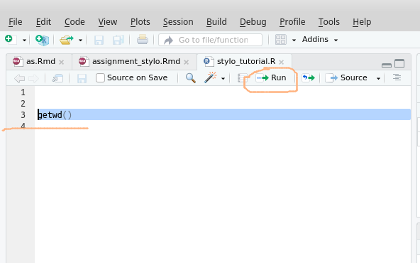

## Executing code

The **Console** is the heart and engine of R. This is where your code actually runs and this is the place where you can see output of your commands. You can go and feed commands directly to the console. Note that you can execute only one line at a time.

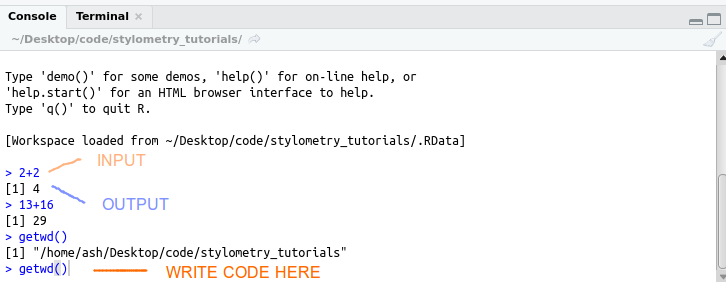

## *stylo* package

First you need to install the package *stylo* as it doesn’t come with R by default

```r
install.packages("stylo")
```

Once you have it installed in your system, you don’t need to reinstall it every time!

Load the library in memory (you would need to do that every time you reopen the script/project)

```r
library("stylo"")
```

## Main functions

We will cover here four main functions from the *stylo* package

- **stylo()** - main explorative tool that computes distances between given set of texts and performs further visualization;
- **classify()** - machine learning classification of set of texts against the training corpus;
- **rolling.classify()** - a method to attribute sequential overlapping chunks of one text to training corpus classes / authors;
- **oppose()** - finding most distinctive words between two sets of texts using zeta-scores method;

## stylo()

By default **stylo()** function goes to

```
.../WORKING_DIRECTORY/corpus
```

to get the texts for analysis. So make sure you have a folder named **corpus** inside your project/working folder. You need to place texts for analysis in this **/corpus** folder.

Then you can simply run the plain function and stylo GUI should appear in the pop-up window

```r
stylo()
```

**NB** Sometimes Mac users will experience *XQuartz* error and GUI won’t open. It should be easily fixable with installing *XQuartz* package.

## stylo GUI. Input

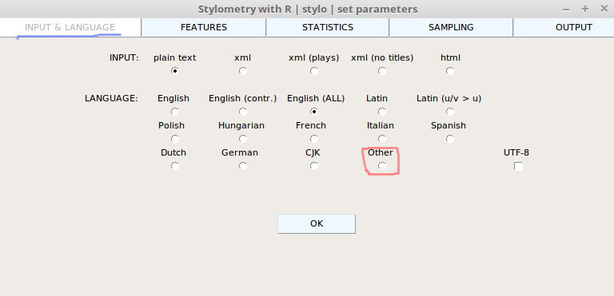

Here you set options for your **input** format (usually you will use default plain .txt files) and **language** of texts. If the language is not listed, select **Other**. Stylo is language-independent and only use language info to cut pronouns.

## stylo GUI. Input

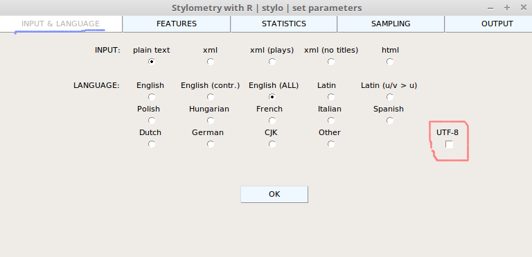

You need to check **UTF-8** box only on Windows (**NB** In current version of the package it assumes UTF-8 by default, instead allowing you use encoding native for your files)

## stylo GUI. Features

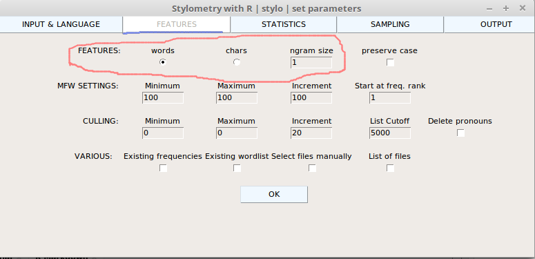

In this tab you define features of texts that will be used for further analysis. You can switch between **word n-grams** and **character n-grams**. Note that the default option is word n-gram with size 1: so basically just a word. Simple classics.

## stylo GUI. Features - MFW

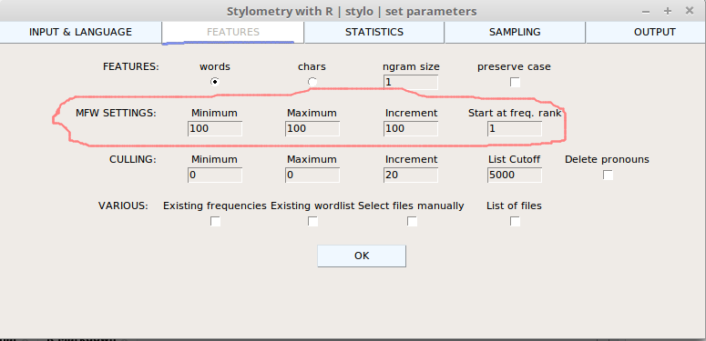

**MFW** stands for the Most Frequent Words. This is the amount of top frequent words that would be used to **calculate distances**. **Start at freq. rank** to skip the top of the wordlist. 100 MFW that start at rank 11 would include 11-110 MFWs.

## stylo GUI. Features - MFW

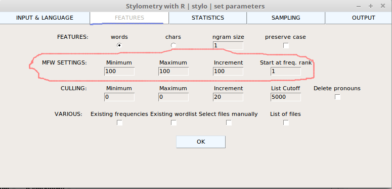

**NB** *Minumum*, *Maximum* and *Increment* settings are used for iterative experiments and are only meaningful for **Consensus Tree** (see the next tab on that). In other cases keep the same values for **Min** and **Max**

## stylo GUI. Features - Culling

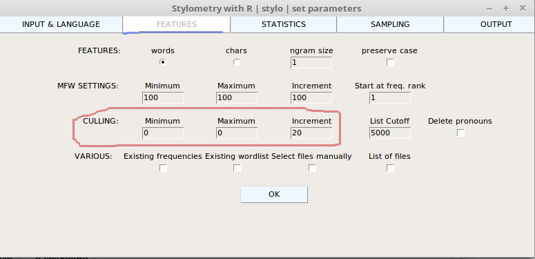

**Culling** is measured in percents and is controlling the amount of MFWs that should be shared by **all texts in corpus**. If **culling=100** then *every* feature from a desired MFW set *should* be present in all texts. All features that do not satisfy this condition **will be culled out** and not used in the analysis.

## stylo GUI. Features - Various

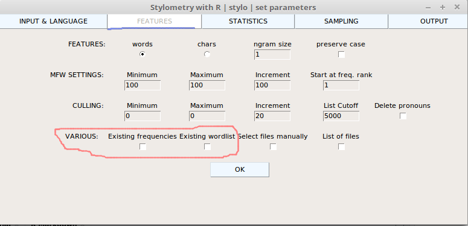

Here you can order the program to use existing **table with frequencies and wordlist**. It makes sense when you already run the experiment and just want to tweak some parameters (like MFWs, distance measures) with existing data in order to save time on text-processing. Also for custom data.

## stylo GUI. Statistics - Clustering

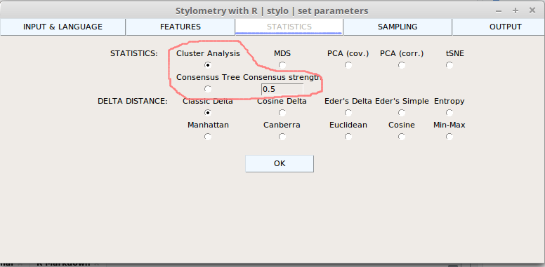

These are implementations of hierarchical clustering techniques used for visualization of final results (the distances of texts between each other). **Consensus tree** tries to form a consensus clusterization based on several experimental runs (that is why you need increments from the **FEATURES** tab)

## stylo GUI. Statistics - 2D

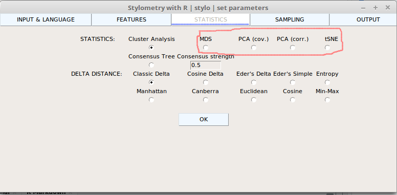

**MDS (Multi-dimensional Scaling)**, **PCA (Principle Component Analysis)**, and **tSNE (Stochastic Member Embedding)** are techinques that reduce dimensionality of data and project the relations of data points onto two-dimensional space.

## stylo GUI. Statistics - Distances

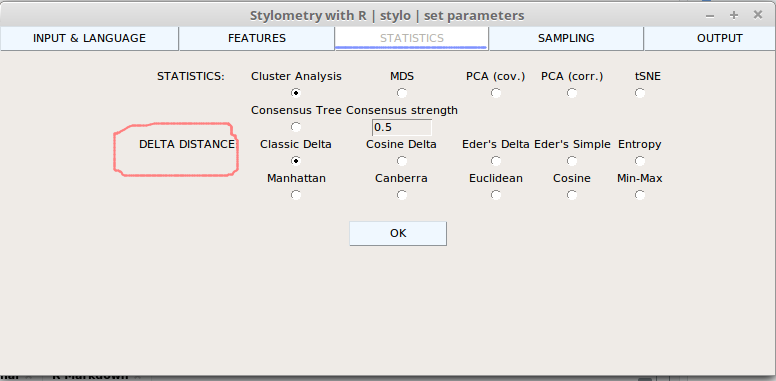

Calculating distances between texts given frequencies of their features (words) is the heart of stylometry. Here you have various measures for that.  
**Hint:** Safe choices in terms of performance and predictability are **classic Burrow’s delta**, **Cosine Delta**, **Min-Max**.

## stylo GUI. Sampling

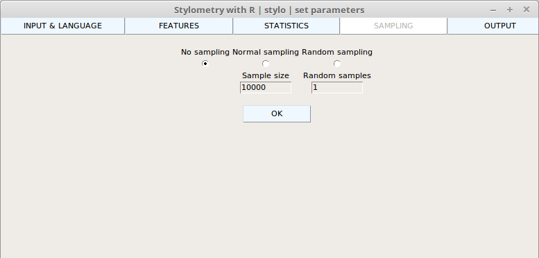

Here you can make samples out of your supplied texts.  
**Normal sampling** is cutting your texts in sequential chunk of *n* size each (in words or specified features)  
**Random sampling** is taking *n* features out of your texts randomly (and you specify how many times it needs to do that)

## stylo GUI. Sampling

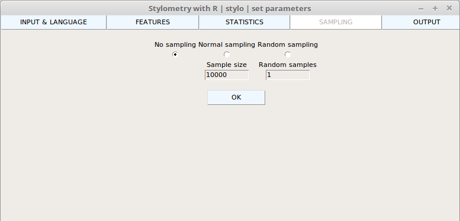

**NB** you can save samples that are generated that way by ticking appropriate box in the **OUTPUT** tab.

## stylo GUI. Output

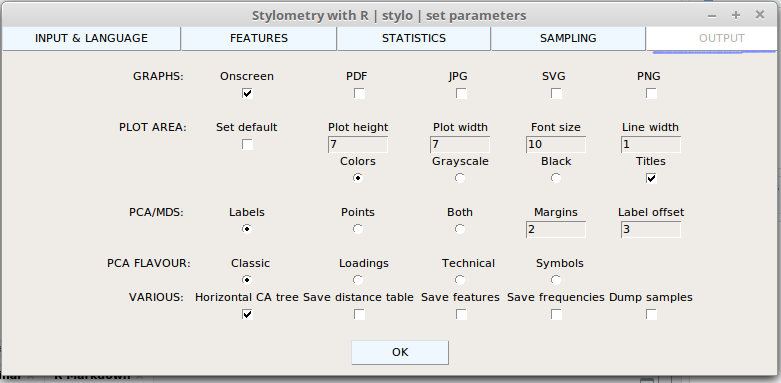

Output options mainly are concerned with visualizations.

## stylo GUI. Output - Data

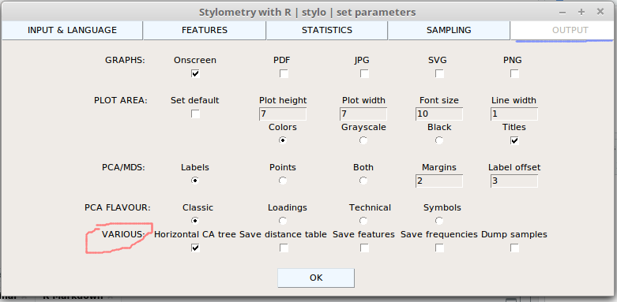

The last row is important. You can save here additional data from your experiments.  
**Distance table** is the final matrix with distances of all texts to each other  
**Features** *actually* used in your experiment (MFWs)

## stylo GUI. Output - Data

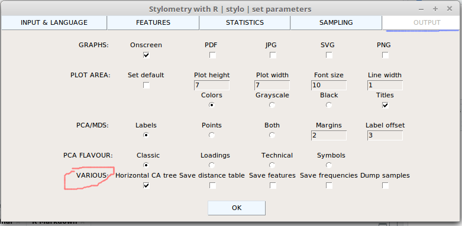

**Frequencies** table include frequencies of all the features (words) in every separate text. Note that numbers here are not absolute, but relative (% of the overall document size). But they are also *not normalized*. Normalized frequencies are actually used by many distance measurements (and, famously, classic Delta)

## stylo output

After each successfull run of **stylo()** output files are automatically generated in your **working directory**. They include:

- **stylo_config.txt**: the configuration file that holds all settings that you used in the last run (input, features, statistics, etc)
- **wordlist.txt**: a list of *all* features (words by default) of your corpus. **NB** you can tweak this list how you want and then run “stylo” with “use existing wordlist” option enabled. This will use words only from your custom wordlist
- **table_with_frequncies.txt**: relative frequencies of all features
- **EDGES**: a comma-separated table for building networks out of your results. The “weight” of links is derived from the “closeness” of neighbours.

## stylo output

If you used **OUTPUT** tab to save additional features you will also find **frequencies_analyzed.txt** and **distance_table.txt**.

All **.txt** tables are separated with spaces and could be opened as sheets (e.g. Excel). Or loaded in R right away for further manipulations:

```r
freq = read.table("table_with_frequencies.txt", sep = " ")
freq[1:10,]
```

```
##     Conrad_Almayer_1895 Conrad_Nostromo_1904 Conrad_Rover_1923
## the           7.3780775            7.4654996          6.109679
## of            3.8732947            4.4216016          3.144307
## and           3.2287910            2.2767085          2.386928
## a             2.0746432            2.5258861          2.697532
## to            2.3067273            2.3356786          2.631135
## he            1.9209660            1.7274772          2.231625
## in            1.8864670            1.8991842          1.638551
## his           1.7970833            1.7425088          1.629548
## i             0.6790027            0.7284542          1.035348
## was           0.9816528            1.1770895          1.439359
##     Kipling_Captains_1896 Kipling_Kim_1901 Kipling_Light_1891
## the              5.514035         6.555638          5.3960105
## of               1.768282         2.612106          2.2514573
## and              2.866083         2.911976          3.2902829
## a                2.506705         2.685920          2.1498476
## to               2.038262         2.115704          2.6137761
## he               1.609154         1.655287          1.3931226
## in               1.253352         1.408009          1.3490026
## his              1.013767         1.094298          0.9545965
## i                1.265868         1.828751          2.3316755
## was              1.037011         0.938365          1.0642280
```

## GUI is boring

If you agree with this statement, then you should know that **stylo()** function can take attributes. **gui=** controls the popping window, so with **gui=FALSE** stylo just runs over your corpus with default settings

```r
stylo(gui=FALSE)
```

How to change that? You may look for attributes in **stylo_config.txt** (for the most part they are self-evident) and then feed your custom settings to the **stylo()** function.

```
##  [1] "corpus.format = \"plain\""           "corpus.lang = \"Other\""
##  [3] "analyzed.features = \"w\""           "ngram.size = 1"
##  [5] "preserve.case = FALSE"               "encoding = \"UTF-8\""
##  [7] "mfw.min = 200"                       "mfw.max = 200"
##  [9] "mfw.incr = 100"                      "start.at = 1"
## [11] "culling.min = 0"                     "culling.max = 0"
## [13] "culling.incr = 20"                   "mfw.list.cutoff = 5000"
## [15] "delete.pronouns = FALSE"             "use.existing.freq.tables = FALSE"
## [17] "use.existing.wordlist = FALSE"       "use.custom.list.of.files = FALSE"
## [19] "analysis.type = \"CA\""              "consensus.strength = 0.5"
## [21] "distance.measure = \"delta\""        "sampling = \"no.sampling\""
## [23] "sample.size = 10000"                 "number.of.samples = 1"
## [25] "display.on.screen = TRUE"            "write.pdf.file = FALSE"
## [27] "write.jpg.file = FALSE"              "write.svg.file = FALSE"
## [29] "write.png.file = FALSE"              "plot.custom.height = 7"
## [31] "plot.custom.width = 7"               "plot.font.size = 10"
## [33] "plot.line.thickness = 1"             "text.id.on.graphs = \"labels\""
## [35] "colors.on.graphs = \"colors\""       "titles.on.graphs = TRUE"
## [37] "label.offset = 0"                    "add.to.margins = 2"
## [39] "dendrogram.layout.horizontal = TRUE" "pca.visual.flavour = \"classic\""
## [41] "save.distance.tables = FALSE"        "save.analyzed.features = FALSE"
## [43] "save.analyzed.freqs = FALSE"         "dump.samples = FALSE"
```

## GUI is boring

So you can write something like that:

```r
stylo(gui = FALSE,
      corpus.lang="Other",
      analyzed.features = "c",
      ngram.size = 4,
      mfw.min=400,
      mfw.max=400,
      analysis.type = "CA")
```

This means that we are running stylo with GUI disabled, language is set to “Other” and we are dealing with 400 most frequent character 4-grams (sequences of 4 characters) with cluster analysis as the output.

## Also…

You can save **stylo()** output as an object in R.  
Let’s say, we are saving it to the variable **experiment1**

```r
experiment1 = stylo(gui = FALSE,
      corpus.lang="Other",
      analyzed.features = "c",
      ngram.size = 4,
      mfw.min=400,
      mfw.max=400,
      analysis.type = "CA")
```

```
## using current directory...
```

```
## Performing no sampling (using entire text as sample)
```

```
## loading Conrad_Almayer_1895.txt  ...
```

```
## loading Conrad_Nostromo_1904.txt ...
```

```
## loading Conrad_Rover_1923.txt    ...
```

```
## loading Kipling_Captains_1896.txt    ...
```

```
## loading Kipling_Kim_1901.txt ...
```

```
## loading Kipling_Light_1891.txt   ...
```

```
## slicing input text into tokens...
```

```
##
## turning words into features, e.g. char n-grams (if applicable)...
```

```
## Total nr. of samples in the corpus: 6
```

```
## ......
## The corpus consists of 2941663 tokens
##
## processing  6  text samples
##
## combining frequencies into a table...
##
##
## culling @ 0  available features (words) 5000
## Calculating z-scores...
##
## Calculating classic Delta distances...
## MFW used:
## 400
## Processing metadata...
##
##
## Assigning plot colors according to file names...
##
##
```

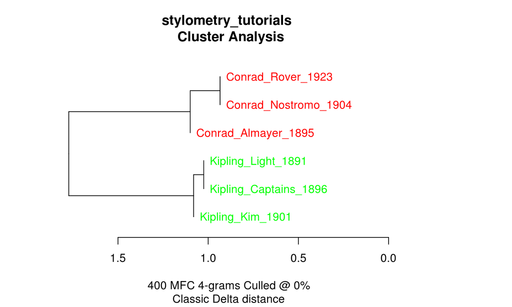

## Also…

Now we have the output stored in the variable **experiment1**. Some parts of data are not accessible otherwise! like table with z-scored frequencies (normalized).  
Use **str()** or **summary()** to see the insides of an object

```r
summary(experiment1)
```

```
##
## Function call:
## stylo(gui = FALSE, corpus.lang = "Other", analyzed.features = "c",      ngram.size = 4, mfw.min = 400, mfw.max = 400, analysis.type = "CA")
##
## Available variables:
##
##            distance.table  final distances between each pair of samples
##                  features  features (e.g. words, n-grams, ...) applied to data
##    features.actually.used  features (e.g. frequent words) actually analyzed
##     frequencies.0.culling  frequencies of words/features accross the corpus
##             list.of.edges  edges of a network of stylometric similarities
##      table.with.all.freqs  frequencies of words/features accross the corpus
##    table.with.all.zscores  z-scored frequencies accross the corpus
##
## These variables can be accessed by typing e.g.:
##
## experiment1$distance.table
```

## Also…

Now we can access content of our variable **experiment1** by indexing it with **$**

```r
experiment1$table.with.all.zscores
```

```
##
## ---------------------------------------
## z-scored frequencies accross the corpus
## ---------------------------------------
##
##                         t h e    t h e        o f      a n d        a n d
## Conrad_Almayer_1895   0.8157696  1.0902085  0.8489762  0.6187712  0.6119394
## Conrad_Nostromo_1904  0.6786285  1.0823862  1.3856226  -1.364372  -1.4107213
## Conrad_Rover_1923     -0.8882253 -0.4536286 0.1560811  -1.0370716 -0.9889548
## Kipling_Captains_1896 -0.5433419 -0.9720785 -1.2893061 0.2948026  0.295079
## Kipling_Kim_1901      1.1492294  0.4044538  -0.3688825 0.250829   0.2686895
## Kipling_Light_1891    -1.2120604 -1.1513414 -0.7324913 1.2370408  1.2239682
##                       i n g        t o        h e      h i s        i n
## Conrad_Almayer_1895   1.5699434  -0.4387696 0.394881   0.9463054  1.1541823
## Conrad_Nostromo_1904  0.0422135  -0.4333716 -0.3907602 0.8855654  1.1123479
## Conrad_Rover_1923     0.5058788  1.0818343  1.766497   0.836369   0.2811632
## Kipling_Captains_1896 -0.8906712 -0.9004576 -0.3227637 -0.967713  -1.191424
## Kipling_Kim_1901      -1.2182793 -0.7500407 -0.2664631 -0.5050079 -0.5998141
## Kipling_Light_1891    -0.0090853 1.4408053  -1.1813911 -1.1955189 -0.7564553
##                       n   t h
## Conrad_Almayer_1895   1.3523718  ...
## Conrad_Nostromo_1904  0.665879   ...
## Conrad_Rover_1923     -0.7678333 ...
## Kipling_Captains_1896 0.4542573  ...
## Kipling_Kim_1901      -0.3630422 ...
## Kipling_Light_1891    -1.3416327 ...
##
## (total number of rows/columns:  6/5000)
```

## classify()

When you call function **classify()** stylo starts to look for texts in two folders:

```
MY_WORKING_DIRECTORY/primary_set
MY_WORKING_DIRECTORY/secondary_set
```

**primary_set** folder in this case is **training corpus**. Texts from this directory will be used by a classification algorithm to learn differences between classes (e.g. authors) of your data. **secondary_set** folder is **test corpus**. Texts from this directory will be used to classify **test set** to classes that were learned with **training corpus**. Evaluation will be done automatically based on matching/mismatching *labels*.

## labels

“stylo” automatically derives information about “classes” of your data from **filenames**. The string *before the first underscore* is assumed to be a class.

So in **“Dickens_Pickwick_Papers_1837.txt”** “Dickens” would be treated as class. If you have several texts of Dickens, you would want to keep standart labels so that “stylo” would know that Dickens texts all form the same class.

## labels

The color-coding in visualizatios is also done based on labels:

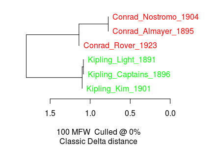

Colors here are not based on the results of *clustering* but use preexisting lables. If some Kipling text would appear in Conrad’s cluster it will still remain green.

Architecture of experiment starts with your *vision of classes* of your training data (what texts you want to test against which classes - is it **gender, authorship, genre** etc.?)

## classify() GUI

In general **classify()** GUI repeats the **stylo()** GUI: you have control over your input, features etc.

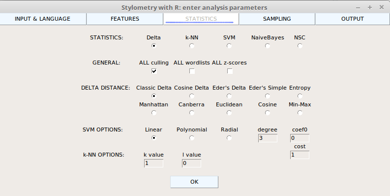

Only **STATISTICS** tab differs significantly

## classify() GUI - Machine learning

You can use distance measures to perform machine learning. Regression algorithm based on Delta will learn differences between your classes in **primary_set**.

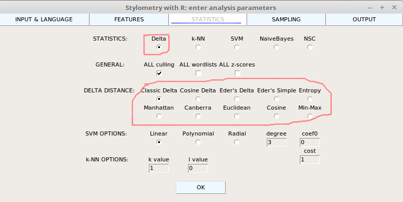

## classify() GUI - Machine learning

However you can choose to perform more powerful machine learning techniques that will directly use feature frequencies. **SVM (Support Vector Machine)** is probably the most reliable choice with high performance.

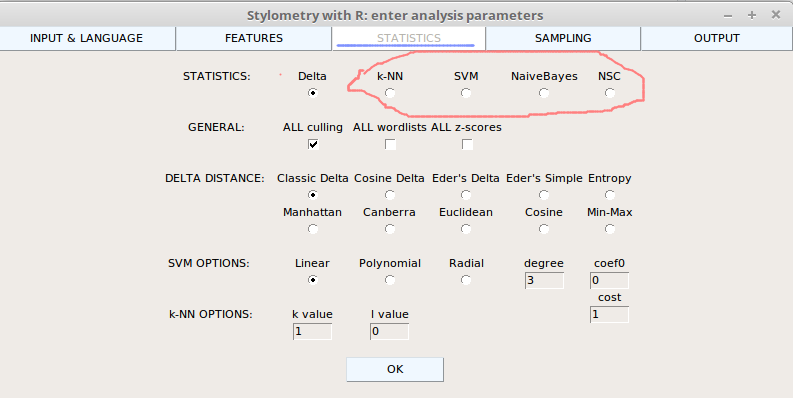

## classify() GUI - Machine learning

**NB**  
**classify()** function gives the **success rate** as an input (instead of visualization). This is our goal when doing machine classification: to know how good is performance of a classifier when it is “guessing” classes in the **test set** against **training set** and what are misatributions.

You can run big experiments in the loop with **gui=FALSE** and change parameters of your model for each iteration (different MFWs, sample sizes, culling, etc.).

## rolling.classify()

rolling.classify() performs *sequential text classification*: it breaks tested text to overlapping (rolling) slices and then tries to attribute each slice to the classes in training corpus. Useful for the cases of multiple authorship.

The training and classifcation is performed in the same machine-learning fashion from **classify()**:

1. learn differences between classes in training corpus;
2. guess class of the text slice-by-slice

By default it looks for texts in two folders: **reference set/** for training corpus (classes to be attributed) and **test_set/** (text in question).

## rolling.classify()

The function doesn’t have GUI, so it takes tinkering with arguments to run it:  
In this example we have two texts of Ward and two texts of Woolf as **reference set** and *Night and day* novel (Woolf) in **test set**

```r
rolling.classify(analyzed.features="w",
                 ngram.size = 1,
                 mfw=500,
                 slice.size = 5000,
                 slice.overlap = 500
                 classification.method="svm")
```

## rolling.classify()

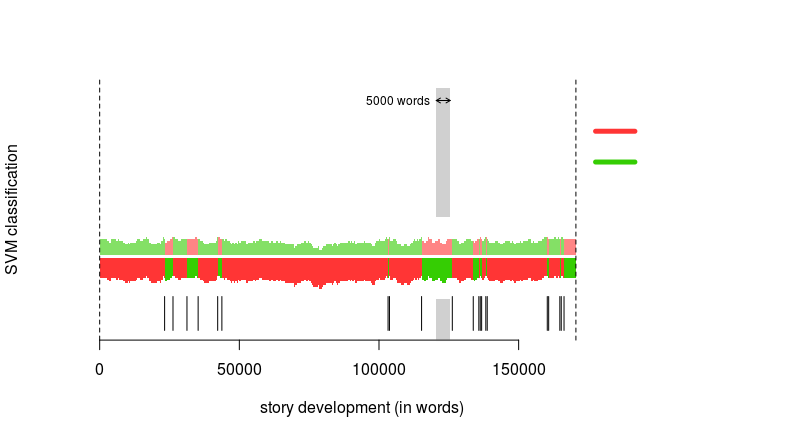

## oppose()

**oppose()** function is used to find most distinctive words in two sets of texts.  
It also uses same directories to look for these two sets:

```
MY_WORKING_DIRECTORY/primary_set
MY_WORKING_DIRECTORY/secondary_set
```

Now there are no hierarchical relations between these folders (as in classification task). It’s just a head-to-head comparision.

## oppose()

**oppose()** is based on *zeta-scores*. It is assigning this score to words in two sets based on their mutual occurence.  
To do that both sets are sliced to some equally-sized pieces. Then probability of occurence of words *within these chunks* is tested. If some word will appear in **all chunks** of **primary set** and never appear in chunks of **secondary set** then:

- zeta-score of this word for **primary set** will be equal to 1.
- zeta-score of this word for **secondary set** will be equal to -1.

In general this means that very frequent words shared in language will always appear across chunks in both sets and would be assigned neutral zeta-scores (around 0). On the other hand, medium-frequency and rare words with variation in their use across two sets will score the most.

## oppose() GUI

**NB** oppose() GUI doesn’t have an option for setting language; it uses English by default. If your corpus is in the other language you need to set it manually running **oppose()** with attribute **corpus.lang=**

```r
oppose(corpus.lang = "Other")
```

## oppose() GUI

**Slice Length** is the size of chunk that you would use to cut texts. Default is 3000 features (words).

## oppose() GUI

**Slice Overlap** is the amount of overlap between your chunks when cutting texts. So with **slice length** 1000 and overlap 100, text will be sliced in first 1-1000 words, then 900-1900 etc. This is used to decrease arbitrariness of cuts.

## oppose() GUI

**Occurence treshold** sets a limit for word appearances to be scored. By default only words with frequency over 2 could be scored.

## oppose() GUI

**Filter treshold** sets limit for zeta-scores values. By default only words with more than 0.1 score will be included in results.

## oppose() GUI

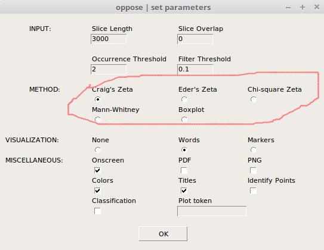

Different variants of calculating zeta-scores. Original author of the method is Hugh Craig. See his book co-authored with Arthur Kinney *Shakespeare, Computers and the Mystery of Authorship (2009)*